SKY130 StrongARM comparators | why ±1 mV fails, and a trim that fixes it

# Correct before the deadline - or NONE?

**Comparator Atlas | Wei-Lun Hsu - National Tsing Hua University**

Which compared SKY130 StrongARM design is correct at every included sampled point before the deadline? Specify the input band, inspect failures, then compare mean energy among qualified designs. If none qualifies, the answer is NONE.

Notebook [(public copy)](https://github.com/WLHsu0827/sscs-ose-code-a-chip.github.io/blob/wlhsu0827-comparator-atlas-isscc27/ISSCC27/submitted_notebooks/comparator_atlas/Comparator_Atlas.ipynb) | Poster [(public copy)](https://github.com/WLHsu0827/sscs-ose-code-a-chip.github.io/blob/ff6fdb8c85e81fe465db1979c44372f19c311c17/ISSCC27/submitted_notebooks/comparator_atlas/results/study/Comparator_Atlas_Poster.pdf)

All controls use stored measurements; no simulation, interpolation or independent physical qualification occurs here.

Opened as a single downloaded file? Folder links need the complete entry folder; each is followed by a *public copy* on GitHub, pinned to a published commit with identical bytes (reader documents follow the submitted branch).

## 1. Specify, qualify, then compare energy

**Calibrated SCHEMATIC only:** local_boundary; all 49 controlled-width-stress conditions. Both signs at the included finite sampled inputs through 30 mV. These six samples and six deadlines form 36 specification cells: 28 NONE, 5 selected and 3 lower-energy control. No continuous-input guarantee.

Minimum |sampled input| Deadline

Every point must be correct before the deadline. Only qualifying designs are ranked by measured mean core energy over the full 20-30 ns cycle, excluding drivers and calibration/controller infrastructure. NONE has null energy/limits. Exact energy ties are all disclosed; the original design order breaks ties.

Different input-band energies are not a same-specification energy improvement.

### 2. Why a circuit is disqualified: keyed observations, not a guessed cause

The same 20 selected +/-1 mV wrong samples remain wrong at 2 ns. A wrong-sign decision is not an unresolved (null-latency) decision. Condition, width stress and trim code identify records, not a physical failure mechanism. Exact matched identities and transitions [(public copy)](https://github.com/WLHsu0827/sscs-ose-code-a-chip.github.io/blob/798f49838947a7d65e343d4325b72d1cd303b88a/ISSCC27/submitted_notebooks/comparator_atlas/results/study/specification_map/summary.json).

**Stored map: inspect the selected design's individual cells**

Inspect compared design Policy All 49 conditions are required here

Correct Wrong Unresolved Calibration unavailable Zero input, unscored

**Static fallback: the exact sampled choices, readable without JavaScript**

| min_abs_input_mV | deadline_ns | choice | mean_core_energy_fJ | min_sampled_margin_ps | max_sampled_core_energy_fJ |
| --- | --- | --- | --- | --- | --- |
| 1.000 | 1.000 | No feasible compared design | NaN | NaN | NaN |
| 3.000 | 1.000 | lvt_balanced_4b | 249.655 | 154.517 | 363.217 |
| 30.000 | 1.000 | lvt_base_3b | 150.531 | 118.731 | 212.406 |
| 10.000 | 2.000 | lvt_base_3b | 152.662 | 915.796 | 220.325 |
| 10.000 | 0.750 | lvt_balanced_4b | 247.618 | 74.516 | 355.030 |
| 30.000 | 0.500 | No feasible compared design | NaN | NaN | NaN |

All records are retained in the integrated decision JSON [(public copy)](https://github.com/WLHsu0827/sscs-ose-code-a-chip.github.io/blob/a5333406b3f08d5da2cf7ca35ef4fcf7a1a69326/ISSCC27/submitted_notebooks/comparator_atlas/results/study/decision_data.json) and the unchanged source tables. The waveform lab below remains eight declared examples, not raw evidence for every key.

## Study design and aggregate schematic results

The schematic study uses ngspice 47 and 49 × 2 declared operating cases: 45 PVT combinations plus four nominal stress controls per design. The selected circuit contains 27 transistor instances, including physical trim branches.

With the same local calibration, a 1 ns deadline and sampled |input| ≥ 1 mV, correct-point coverage changes from 79.1% to 94.9%. Mean core-rail energy changes by +75.9% over 392 matched points; this excludes external drivers and calibration infrastructure.

Selected circuit: `lvt_balanced_4b`.

The transistor gate-area proxy is 1.90x the original. Matched mean core-rail energy is **143.01 → 251.53 fJ/cycle**. This is not a claim of lower area, lower system power, silicon yield or a new comparator topology.

The comparison uses the same local calibration policy, input band and deadline. A lower-energy candidate is included to show the accuracy-energy tradeoff.

The PVT comparison is schematic-level. The physical-layout section separately reports nominal code-zero measurements and the remaining slow-corner limitation.

## 27-device circuit topology and trim branches

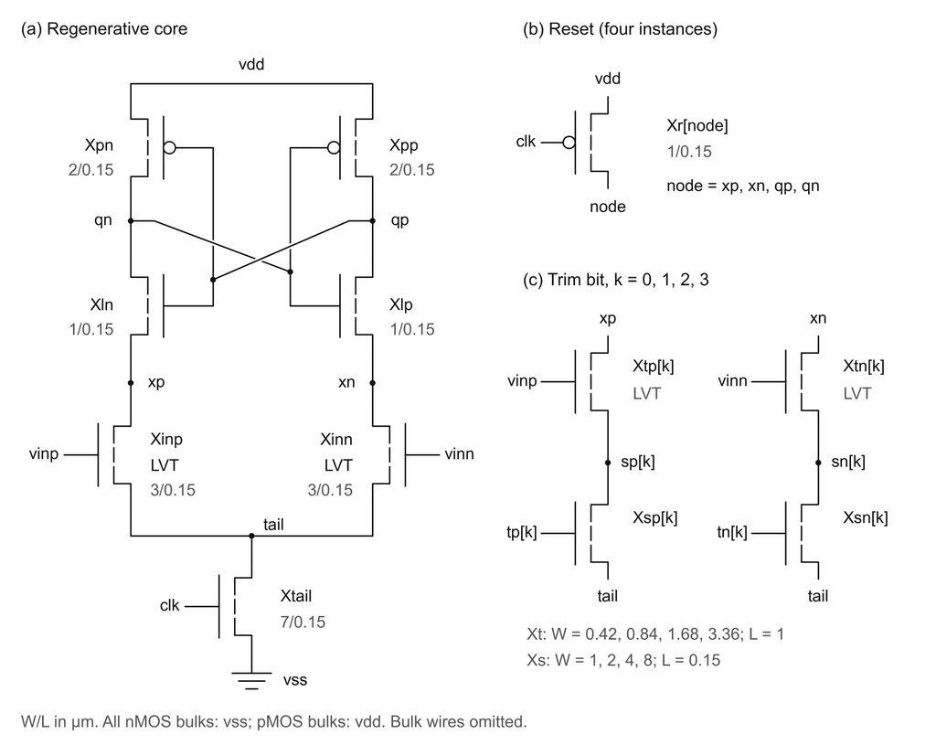

The source-checked MOS schematic shows the cross-coupled core, a reset PFET repeated at the four listed nodes, and one trim bit repeated on both sides for k = 0–3. Filled dots are electrical junctions; unmarked crossings are unconnected. Matching node labels across panels denote the same net. All 27 instances, device flavors and body ties are retained. Vector PDF schematic [(public copy)](https://github.com/WLHsu0827/sscs-ose-code-a-chip.github.io/blob/8011aba5284e15d6ed0498a06c31f20f1b7d62de/ISSCC27/submitted_notebooks/comparator_atlas/results/presentation/circuit_guide.pdf).

## Nine-candidate selection on three declared conditions

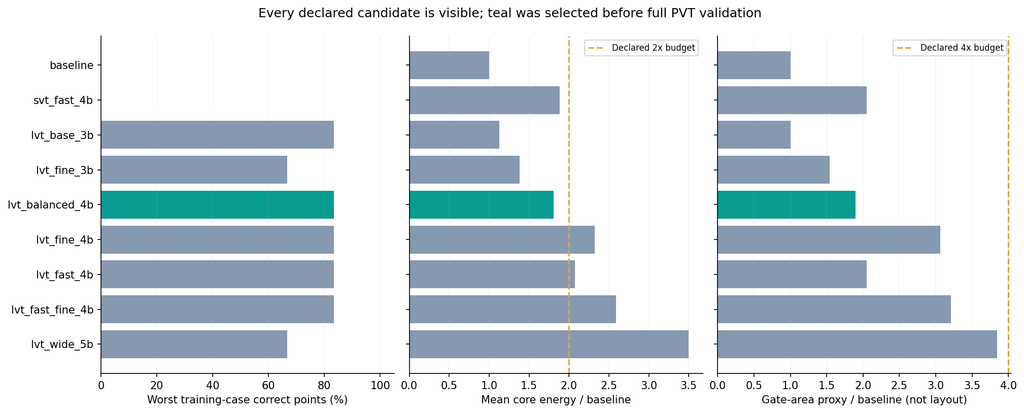

Selection used TT/1.8 V/27 C, SS/1.62 V/-40 C and FF/1.95 V/125 C, six declared input values, and 2x energy / 4x gate-area-proxy budgets. The initial prototype informed the family. The recorded objective and candidate list were frozen before this campaign. No global optimum is asserted.

## Schematic PVT comparison at controlled width stress

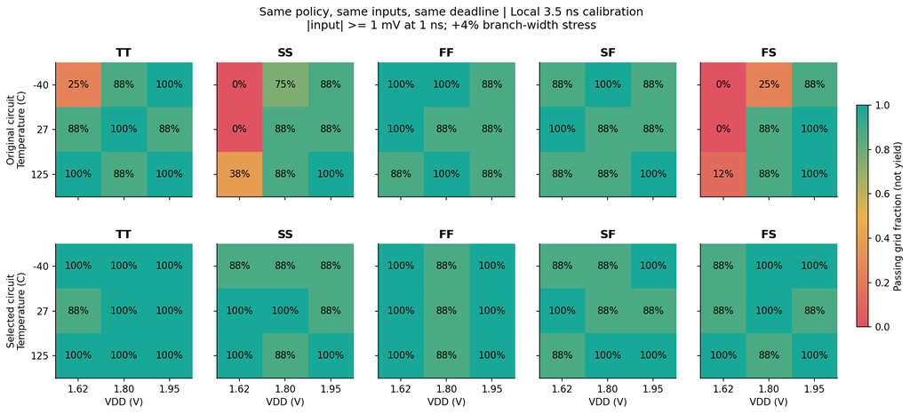

The figure contains the regular 45-condition PVT grid at +4% branch-width stress. All plots and tables are deterministic test coverage, not error probability or manufacturing yield. The four additional nominal stress controls remain in the full table and explorer.

| design_name | policy | points | correct | pass_fraction | unavailable_points | simulated_points | mean_core_energy_fj | refined_points |
| --- | --- | --- | --- | --- | --- | --- | --- | --- |
| baseline | code_zero | 392 | 224 | 0.5714 | 0 | 392 | 137.6 | 2 |
|  | nominal_frozen | 392 | 293 | 0.7474 | 0 | 392 | 142.4 | 3 |
|  | local_boundary | 392 | 310 | 0.7908 | 0 | 392 | 143 | 4 |
|  | deadline_aware | 392 | 310 | 0.7908 | 32 | 360 | 147.9 | 4 |
| lvt_balanced_4b | code_zero | 392 | 268 | 0.6837 | 0 | 392 | 242.8 | 0 |
|  | nominal_frozen | 392 | 316 | 0.8061 | 0 | 392 | 249.3 | 0 |
|  | local_boundary | 392 | 372 | 0.949 | 0 | 392 | 251.5 | 2 |
|  | deadline_aware | 392 | 372 | 0.949 | 0 | 392 | 251.5 | 2 |

### Reserved conditions only

The following table removes the three selection conditions. It is an internal reserved evaluation, not a blinded external benchmark. Unavailable calibration remains a failed coverage point; its energy is not invented.

| design_name | policy | points | correct | pass_fraction | unavailable_points | simulated_points | mean_core_energy_fj | refined_points |
| --- | --- | --- | --- | --- | --- | --- | --- | --- |
| baseline | code_zero | 368 | 214 | 0.5815 | 0 | 368 | 137.8 | 2 |
|  | nominal_frozen | 368 | 279 | 0.7582 | 0 | 368 | 142.5 | 3 |
|  | local_boundary | 368 | 295 | 0.8016 | 0 | 368 | 143.1 | 4 |
|  | deadline_aware | 368 | 295 | 0.8016 | 24 | 344 | 146.7 | 4 |
| lvt_balanced_4b | code_zero | 368 | 252 | 0.6848 | 0 | 368 | 242.6 | 0 |
|  | nominal_frozen | 368 | 298 | 0.8098 | 0 | 368 | 249.2 | 0 |
|  | local_boundary | 368 | 349 | 0.9484 | 0 | 368 | 251.1 | 2 |
|  | deadline_aware | 368 | 349 | 0.9484 | 0 | 368 | 251.1 | 2 |

## Post-selection lower-energy control

This is an explicitly **post-selection ablation** of an existing lower-energy LVT candidate. It uses the same 49 conditions and input grid with separate numerical refinement; it does not replace the frozen original selection or create a newly blinded benchmark.

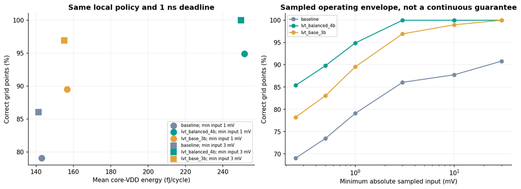

### Local calibration, 1 ns, sampled |input| ≥ 1 mV

| design | correct | points | grid_coverage | fully_passing_conditions | conditions | worst_condition_coverage | mean_core_energy_fj | simulated_points | gate_area_proxy_um2 |
| --- | --- | --- | --- | --- | --- | --- | --- | --- | --- |
| baseline | 310 | 392 | 0.7908 | 16 | 49 | 0 | 143 | 392 | 10.83 |
| lvt_balanced_4b | 372 | 392 | 0.949 | 29 | 49 | 0.875 | 251.5 | 392 | 20.55 |
| lvt_base_3b | 351 | 392 | 0.8954 | 18 | 49 | 0.25 | 156.6 | 392 | 10.83 |

### Same policy and deadline, sampled |input| ≥ 3 mV

| design | correct | points | grid_coverage | fully_passing_conditions | conditions | worst_condition_coverage | mean_core_energy_fj | simulated_points | gate_area_proxy_um2 |
| --- | --- | --- | --- | --- | --- | --- | --- | --- | --- |
| baseline | 253 | 294 | 0.8605 | 40 | 49 | 0 | 141.3 | 294 | 10.83 |
| lvt_balanced_4b | 294 | 294 | 1 | 49 | 49 | 1 | 249.7 | 294 | 20.55 |
| lvt_base_3b | 285 | 294 | 0.9694 | 43 | 49 | 0.3333 | 155 | 294 | 10.83 |

All-sampled-points passing is not a guarantee between sample points. Worst-condition coverage and the count of fully passing conditions are reported alongside the mean. Neither circuit is asserted best for every energy, input-resolution or interface requirement.

### Calibration workload, not implemented on-chip calibration cost

| design | minimum_distinct_probes | maximum_distinct_probes | median_distinct_probes | maximum_offline_simulated_duration_ns |
| --- | --- | --- | --- | --- |
| baseline | 37 | 139 | 48.0 | 4170 |
| lvt_balanced_4b | 53 | 64 | 64.0 | 1920 |
| lvt_base_3b | 37 | 48 | 48.0 | 1440 |

A distinct probe represents an offline three-cycle simulation. Reference/input generation, drivers, control logic and storage are not included in core energy. The additional control has not inherited the original/selected circuits' input-interface stress results.

### Matched failures and sampled specification limits

The following static tables use only the calibrated schematic 49-condition controlled-width-stress domain, not the nominal RC grid. Every included signed sample must be correct before mean full-cycle core energy ranks qualified designs. NONE means no feasible compared design and retains null metrics (shown as NaN), not a best-average substitute. The 36 choices remain 28 NONE / 5 selected / 3 control.

| min_abs_input_mV | deadline_ns | choice | mean_core_energy_fJ | min_sampled_margin_ps | max_sampled_core_energy_fJ |
| --- | --- | --- | --- | --- | --- |
| 1 | 1 | No feasible compared design | NaN | NaN | NaN |
| 3 | 1 | lvt_balanced_4b | 249.7 | 154.5 | 363.2 |
| 30 | 1 | lvt_base_3b | 150.5 | 118.7 | 212.4 |
| 10 | 2 | lvt_base_3b | 152.7 | 915.8 | 220.3 |
| 10 | 0.75 | lvt_balanced_4b | 247.6 | 74.52 | 355 |
| 30 | 0.5 | No feasible compared design | NaN | NaN | NaN |

Margins are deadline minus recorded decision time; maxima are observed core energies over the same band. They are not noise/jitter/PVT confidence bounds, timing signoff, worst-cycle guarantees or total system/calibration cost. All exact limiting ties and source hashes are retained in the auditable JSON [(public copy)](https://github.com/WLHsu0827/sscs-ose-code-a-chip.github.io/blob/798f49838947a7d65e343d4325b72d1cd303b88a/ISSCC27/submitted_notebooks/comparator_atlas/results/study/specification_map/summary.json).

#### Exactly matched 1 ns to 2 ns samples, |input| ≥ 1 mV

| design | deadline_ns | correct | wrong | unresolved |
| --- | --- | --- | --- | --- |
| baseline | 1 | 310 | 22 | 60 |
| baseline | 2 | 339 | 31 | 22 |
| lvt_balanced_4b | 1 | 372 | 20 | 0 |
| lvt_balanced_4b | 2 | 372 | 20 | 0 |
| lvt_base_3b | 1 | 351 | 32 | 9 |
| lvt_base_3b | 2 | 357 | 35 | 0 |

Baseline's 60 unresolved samples become 29 correct, nine wrong and 22 unresolved; the control's nine become six correct and three wrong. Longer deadlines need not reduce wrong counts. Selected's 20 wrong samples are exactly the same keyed set at both deadlines, all at +/-1 mV. Locations and local calibration codes below are observations, not evidence of trim saturation, residual offset or noise.

| case_id | input_mv | trim_code | outcome_1ns | outcome_2ns |
| --- | --- | --- | --- | --- |
| FF \| 1.80 V \| -40 C \| skew +4% | -1.0 | -4.0 | wrong | wrong |
| FF \| 1.80 V \| 125 C \| skew +4% | 1.0 | -9.0 | wrong | wrong |
| FF \| 1.80 V \| 27 C \| skew +4% | -1.0 | -6.0 | wrong | wrong |
| FS \| 1.62 V \| -40 C \| skew +4% | -1.0 | -1.0 | wrong | wrong |
| FS \| 1.62 V \| 27 C \| skew +4% | 1.0 | -2.0 | wrong | wrong |
| FS \| 1.80 V \| 125 C \| skew +4% | -1.0 | -3.0 | wrong | wrong |
| FS \| 1.95 V \| 27 C \| skew +4% | -1.0 | -3.0 | wrong | wrong |
| SF \| 1.62 V \| -40 C \| skew +4% | 1.0 | -3.0 | wrong | wrong |
| SF \| 1.62 V \| 125 C \| skew +4% | -1.0 | -6.0 | wrong | wrong |
| SF \| 1.80 V \| -40 C \| skew +4% | -1.0 | -4.0 | wrong | wrong |
| SF \| 1.80 V \| 27 C \| skew +4% | 1.0 | -7.0 | wrong | wrong |
| SF \| 1.95 V \| 27 C \| skew +4% | -1.0 | -8.0 | wrong | wrong |
| SS \| 1.62 V \| -40 C \| skew +4% | 1.0 | -2.0 | wrong | wrong |
| SS \| 1.80 V \| -40 C \| skew +4% | -1.0 | -2.0 | wrong | wrong |
| SS \| 1.80 V \| 125 C \| skew +4% | -1.0 | -3.0 | wrong | wrong |
| SS \| 1.95 V \| -40 C \| skew +4% | -1.0 | -3.0 | wrong | wrong |
| SS \| 1.95 V \| 27 C \| skew +4% | 1.0 | -4.0 | wrong | wrong |
| TT \| 1.62 V \| 27 C \| skew +4% | -1.0 | -2.0 | wrong | wrong |
| TT \| 1.80 V \| 27 C \| skew +8% | 1.0 | -8.0 | wrong | wrong |
| TT \| 1.80 V \| 27 C \| skew -8% | -1.0 | 8.0 | wrong | wrong |

## Retained waveforms: wrong-sign, unresolved and correct decisions

**Eight declared examples from retained waveforms** compare the complementary output rails against each recorded deadline. These are representative teaching cases, not the raw trace for every atlas cell and not a new validation set. Changing the deadline reads the same trace; it does not run SPICE or alter a circuit.

Actual stored example Decision deadline:

Q+ Q- Clock Horizontal dotted lines: fixed 80% / 20% supply thresholds

**CORE-RAIL ENERGY**

**RETAINED DECISION-TIME MEASUREMENT**

Core energy is measured over the entire 10 ns cycle and does not shrink when the display deadline moves. Cursor voltages use the original waveform samples; latency is a sampled measurement, not an exact crossing. For layout examples, the original 1 ns pilot remains failed even when an individual trace resolves by 2 ns.

Scope: RC timing and energy are results of the archived simulation decks; extracted-model physical fidelity remains unqualified. RC-versus-C differences are not isolated resistance effects or silicon predictions.

**Source record**

## Calibration deadline and scored input band

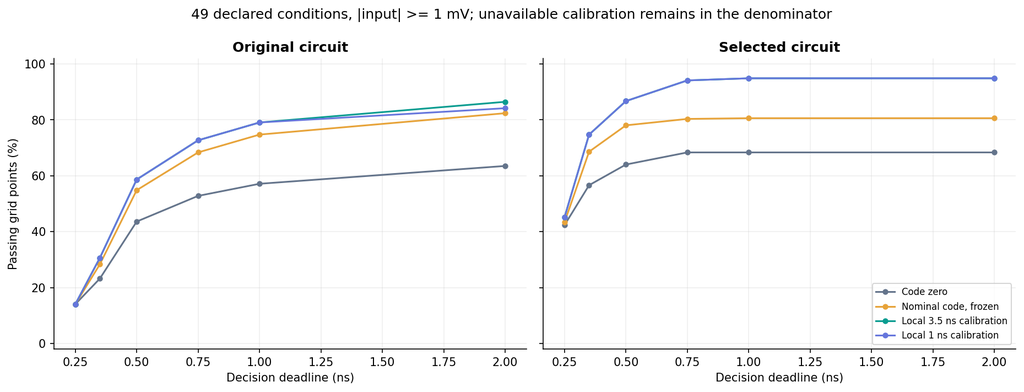

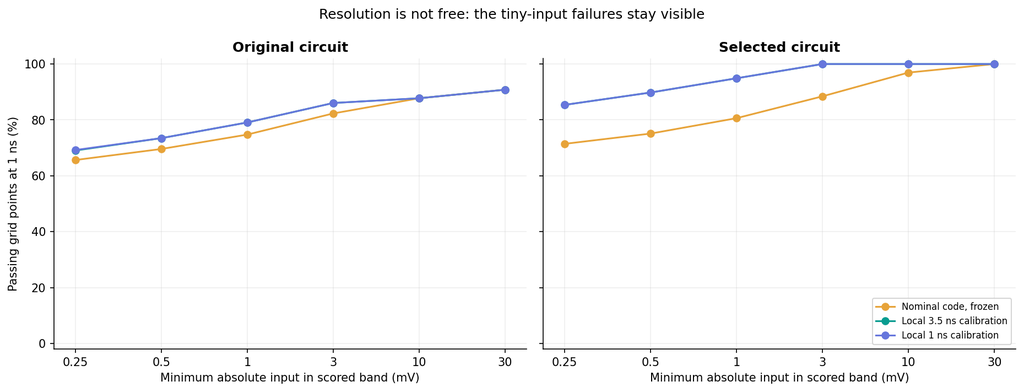

The hardware comparison uses the same local 3.5 ns calibration policy. The 1 ns policy is a separate ablation: it minimizes the finite-deadline decision interval rather than only its long-deadline offset. A failed calibration is explicitly unavailable, not silently replaced by code zero.

## Retained cold-corner schematic waveform

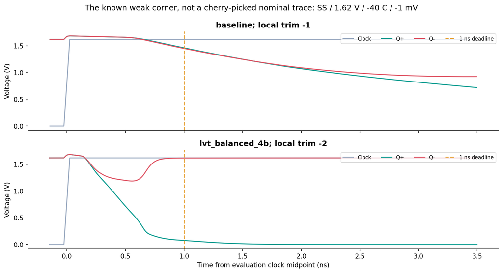

This condition was known to be weak in the first prototype and was included in selection. It illustrates mechanism; the reserved/full PVT tables, not this one waveform, support generalization within the declared grid.

## Input history, settling and interface perturbations

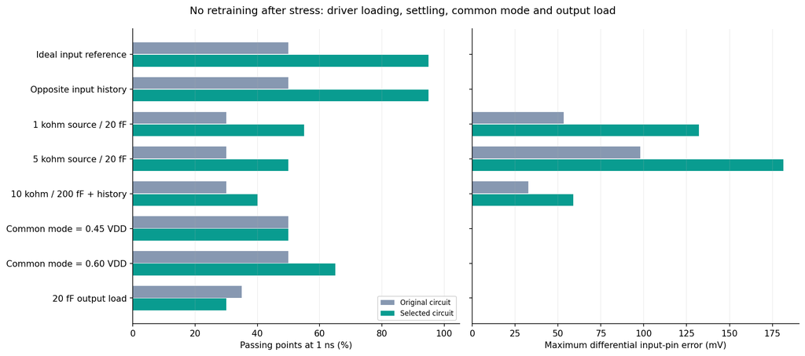

Five nominal/extreme PVT conditions, four inputs, and eight explicitly defined stresses per design. Codes are frozen before perturbing the interface. The history step changes the external input at 18 to 18.05 ns; evaluation starts at 22.025 ns. Pin error includes deterministic settling and kickback, not random noise.

Selected design at all 49 conditions for +/-1 mV and both local policies; baseline at five extreme/nominal conditions; additionally every validation run with an output decision margin within 5 mV of a rail threshold. All six reporting deadlines are checked. Initially sensitive points are subsequently refined under the recorded halving policy. Refinement limits are identical outcomes, at most 1% core-energy difference and at most 20 ps resolved-latency difference. These checks are not production signoff.

## Adopted area version: single-row-local-pitch-b1

**All-material GDS bbox: matched a1 2074.254 to b1 1873.3 um2 (9.688013% less).** Matched adopted a1 measures 121.8 x 17.03 um; adopted b1 measures 110 x 17.03 um. Wells, body contacts, guards and shields are included; only TEXT is excluded. The 27 guarded MOS devices, 15 ports, device dimensions, flavors, junctions, pair order, mirroring, vertical placement and local escapes remain fixed. Fixed local intervals are 3.8/4.2 um, with horizontal endpoints following placement. No matching benefit or diffusion sharing is claimed.

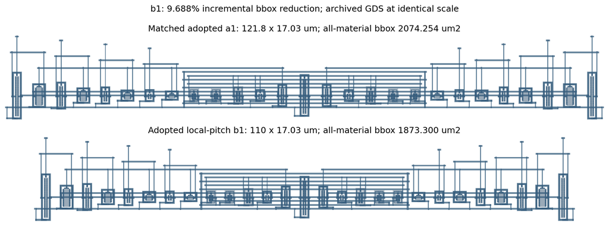

The separate nominal code-zero comparison completed 1440 transients and 720 qualified 10/5 ps pairs, with 180 points per layout and C/RC mode. Conditions were known before qualification. Both layouts and modes are correct at all points at the fixed 2 ns primary deadline. At 1 ns, C-only retains 170 correct and 10 unresolved points. RC improves from 156 correct / 24 unresolved to 158 correct / 22 unresolved, only at SS / 1.62 V / 125 C / +/-10 mV. FS unresolved points remain; unresolved latencies stay null. No previously correct point is lost; no wrong or unresolved primary point is introduced.

| version | mode | points | 1ns correct/wrong/unresolved | 2ns correct/wrong/unresolved | mean core fJ | max core fJ | worst recorded ns | minimum 2ns margin ps |
| --- | --- | --- | --- | --- | --- | --- | --- | --- |
| Matched adopted a1 | C | 180 | 170/0/10 | 180/0/0 | 353.340125 | 491.158867 | 1.389035 | 610.965055 |
| single-row-local-pitch-b1 | C | 180 | 170/0/10 | 180/0/0 | 346.542852 | 481.773778 | 1.346432 | 653.567939 |
| Matched adopted a1 | RC | 180 | 156/0/24 | 180/0/0 | 421.044730 | 584.441046 | 1.810632 | 189.368192 |
| single-row-local-pitch-b1 | RC | 180 | 158/0/22 | 180/0/0 | 412.879469 | 573.364399 | 1.760276 | 239.723517 |

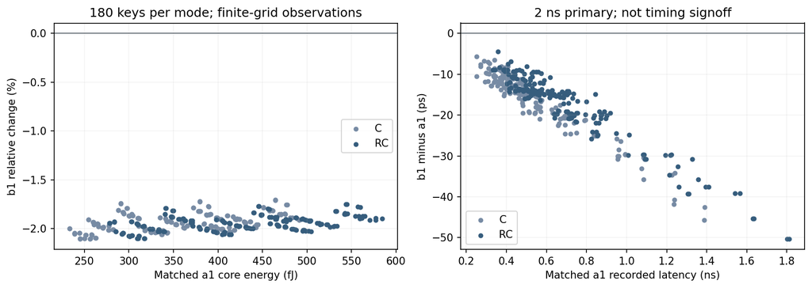

From matched adopted a1 to b1, mean RC core energy decreases from 421.044730 to 412.879469 fJ (-1.939286%, ratio of means; -1.945659%, mean per-point change), and worst recorded latency from 1.810632 to 1.760276 ns. Minimum observed 2 ns margin increases from 189.368 to 239.724 ps. Mean C-only energy decreases from 353.340125 to 346.542852 fJ (-1.923720%, ratio of means; -1.932155%, mean per-point change). All 180 energy and latency pairs decrease in each mode. The decreases are numerically consistent in these decks, but approximately 2% energy and 4-51 ps timing changes are not robust physical PPA benefits. The 1% / 20 ps acceptance criteria are not uncertainty bounds; maximum actual step discrepancies are 0.022142% energy and 9.631727 ps latency. There are 720 finest 5 ps traces and 1440 two-deadline rows, not 1440 finest independent experiments. Max energy is FF / 1.95 V / 125 C / -3 mV; worst recorded timing is FS / 1.62 V / -40 C / -3 mV, in all four populations.

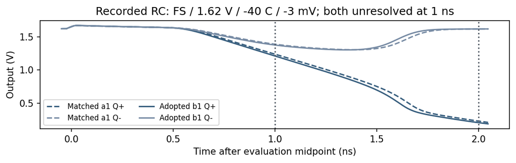

The candidate passed 14 native checks on one actual DRC attempt before full45 qualification. Both native proofs and extracts were reused, not rerun; publication added no EDA/SPICE execution. New local planning safety is at least 0.20 um; unchanged inherited global M3 margin is 0.16 um. The recovered pre-route MAG is distinct from final routed MAG. Fresh adopted-a1 control C/RC readings match the archived adopted-a1 population exactly at all six helper deadlines; this was measured, not assumed. Historical traces are not credited as new executions. C-only is not independent physical ground truth.

**Archived RC-deck outcomes; model physical fidelity not yet qualified.** This nominal comparison is not the calibrated 49-condition width-stress study or a post-layout noise, mismatch, trim, silicon, independently qualified PEX or signoff result. Core energy excludes drivers, controller and calibration infrastructure. All versioned native/raw records, 720 numerical receipts, keyed transitions, limiting points and offline remeasurement [(public copy)](https://github.com/WLHsu0827/sscs-ose-code-a-chip.github.io/blob/db82273a5df8b73d39ebf20593309e433d1a1d50/ISSCC27/submitted_notebooks/comparator_atlas/layout_single_row/v2/README.md). The prior adopted a1 version [(public copy)](https://github.com/WLHsu0827/sscs-ose-code-a-chip.github.io/blob/309dc3ad76de15818e9c9673a4dfc2aead2fb4c6/ISSCC27/submitted_notebooks/comparator_atlas/layout_single_row/v1/README.md) and original studies below remain preserved history, not candidate data.

## Historical original compact control: geometry and pilot

The original compact control, not the adopted b1 layout, has recorded GDS, named-style DRC, independent LVS, wrong-net/bulk/width/SVT-LVT negative controls, and separate connectivity/C/RC exports. The original layout development used **five code-zero conditions**. The following expanded study covers 45 PVT conditions with the same nominal geometry. Neither is a post-layout reproduction of the calibrated width-stress study.

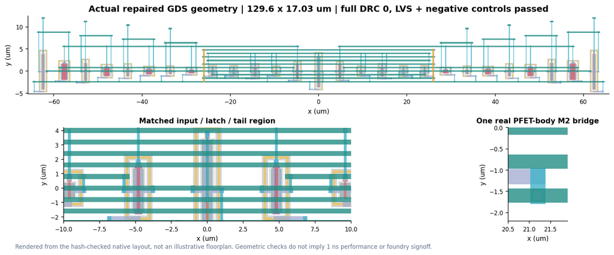

| layout | bbox_area_um2 | m2_union_area_um2 | rc_resistors | rc_capacitors | listed_rc_capacitance_ff | drc_errors | lvs_and_negative_controls |
| --- | --- | --- | --- | --- | --- | --- | --- |
| initial_legal_comb | 4282 | 520.4 | 672 | 319 | 266.5 | 0 | pass |
| balanced_legal_r1 | 3297 | 433.1 | 675 | 321 | 256.8 | 0 | pass |
| repaired_compact | 2207 | 80.38 | 675 | 319 | 181.4 | 0 | pass |

The compact predecessor failed M2 pad-notch spacing and was never simulated. Four M2 bridges repair it without changing devices, pins or the other mask geometry. Archived-deck differences are measured against the prior *legal balanced layout*, not attributed to the bridges alone. Listed capacitance is a sum of emitted elements, not an effective impedance.

Scope: RC timing and energy are results of the archived simulation decks; extracted-model physical fidelity remains unqualified. RC-versus-C differences are not isolated resistance effects or silicon predictions.

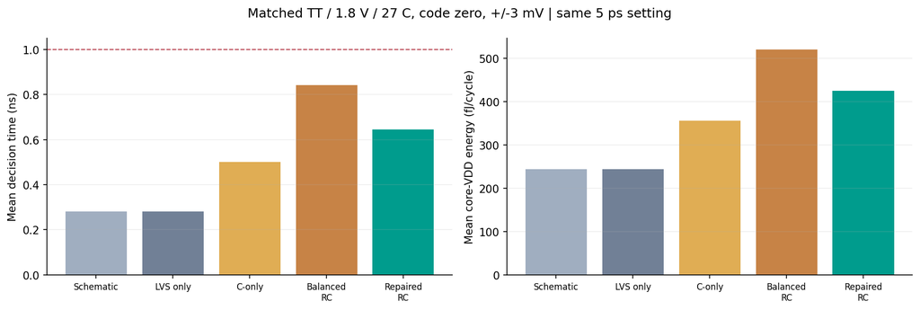

| implementation | mean_delay_ns | mean_core_energy_fj | matched_signed_points |
| --- | --- | --- | --- |
| Schematic | 0.2804 | 244.1 | 2 |
| Repaired Connectivity only | 0.2797 | 244.1 | 2 |
| Repaired C-only | 0.4996 | 355.9 | 2 |
| Previous balanced RC | 0.8429 | 520.8 | 2 |
| Repaired Distributed RC | 0.6451 | 425.4 | 2 |

### Earlier five-condition layout pilot (ngspice 42)

**The original 1 ns pilot still fails:** RC has 12/20 correct points and 8 late SS points. At the already recorded **2 ns window**, all 20 sampled RC points are correct, with retained 10-to-5 ps comparisons meeting the same numerical limits. This is post-hoc characterization, not a relaxed replacement for the original target.

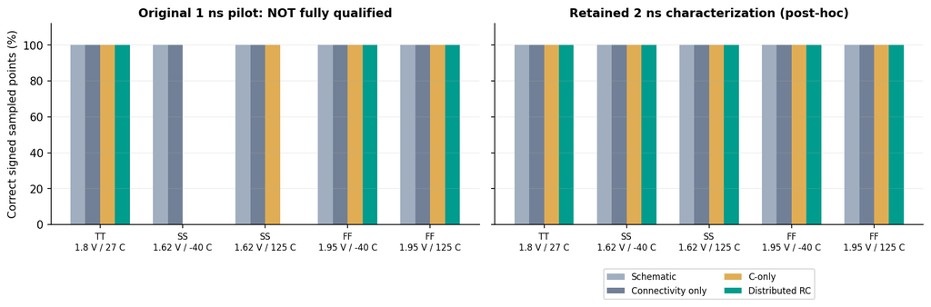

| mode | deadline_ns | sampled_points | correct | wrong | unresolved | scope |
| --- | --- | --- | --- | --- | --- | --- |
| Schematic | 1 | 20 | 20 | 0 | 0 | original pilot |
| Schematic | 2 | 20 | 20 | 0 | 0 | post-hoc retained-window characterization |
| Connectivity only | 1 | 20 | 20 | 0 | 0 | original pilot |
| Connectivity only | 2 | 20 | 20 | 0 | 0 | post-hoc retained-window characterization |
| C-only | 1 | 20 | 16 | 0 | 4 | original pilot |
| C-only | 2 | 20 | 20 | 0 | 0 | post-hoc retained-window characterization |
| Distributed RC | 1 | 20 | 12 | 0 | 8 | original pilot |
| Distributed RC | 2 | 20 | 20 | 0 | 0 | post-hoc retained-window characterization |

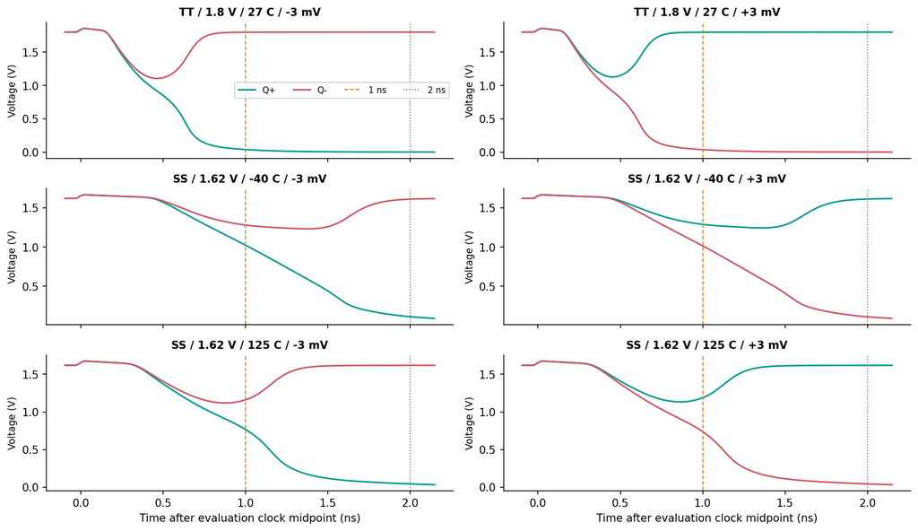

Each mode in this earlier pilot has five conditions times four inputs: 20 points, not 80 RC tests. Its original gated 45-condition extension did not run; 3.5 ns was not evaluated. These records remain separate from the new full-grid study below.

Recorded verification run: [compact-layout repair evidence](https://github.com/WLHsu0827/sscs-ose-code-a-chip.github.io/actions/runs/35945064081). The workflow's failure status reflects the preserved 1 ns performance gate, not a hidden DRC/LVS failure. Source replay instructions bind the original experimental commit.

## Historical original compact control: 45-PVT schematic/RC grid

The following tables and figures describe the original compact control, not candidate data. Its nominal, code-zero schematic and RC circuits were evaluated at five process corners, three supplies and three temperatures: **45 conditions, four signed inputs each, 180 points per mode**. The primary 2 ns deadline was declared before this expanded study; 1 ns is reported alongside it.

**Archived RC decks: 180/180 correct at 2 ns; 156/180 at 1 ns.** The other 24 points are late, with no wrong decisions. All point histories meet the same numerical criteria at 10 and 5 ps.

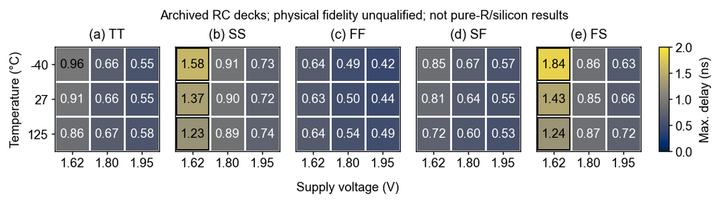

Each cell is the maximum sampled delay over -10, -3, +3 and +10 mV. Black outlines mark a missed 1 ns sample. Five conditions had been observed in the earlier pilot; forty are new post-layout conditions, not a blinded external test.

| implementation | points | correct_at_1ns | correct_at_2ns | mean_core_energy_fj | mean_delay_ns_at_2ns | worst_delay_ns_at_2ns |
| --- | --- | --- | --- | --- | --- | --- |
| Schematic | 180 | 180 | 180 | 245.8 | 0.3033 | 0.738 |
| Extracted RC | 180 | 156 | 180 | 425.5 | 0.7076 | 1.835 |

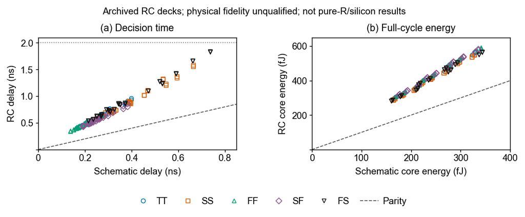

The slowest sampled RC point is **FS / 1.62 V / -40 C / -3 mV: 1.835 ns**. Mean core energy is 245.84 fJ schematic versus 425.49 fJ RC. The mean per-point overhead is 73.45%; the ratio of population means is 73.08%.

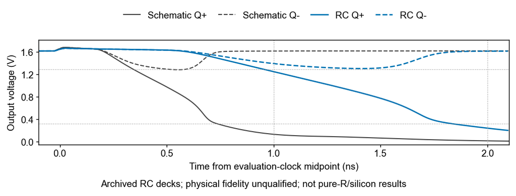

Both modes in this study use ngspice 47, the same pinned SKY130 models, nominal dimensions, code zero, 5 fF output loads, 0.5 VDD common mode and a 10 ns clock with 50 ps edges. This is a finite sampled result, not a noise, mismatch-yield or continuous-input guarantee. It does not retroactively change the earlier 1 ns pilot.

Scope: RC timing and energy are results of the archived simulation decks; extracted-model physical fidelity remains unqualified. RC-versus-C differences are not isolated resistance effects or silicon predictions. Extraction-model evidence and limitations [(public copy)](https://github.com/WLHsu0827/sscs-ose-code-a-chip.github.io/blob/wlhsu0827-comparator-atlas-isscc27/ISSCC27/submitted_notebooks/comparator_atlas/REPRODUCIBILITY.md#archived-rc-model-applicability).

Publication-size vector figures: PVT timing [(public copy)](https://github.com/WLHsu0827/sscs-ose-code-a-chip.github.io/blob/116de18ec95c438b6c28ac3a3e4c339300b71106/ISSCC27/submitted_notebooks/comparator_atlas/results/study/postlayout_pvt45/figures/pvt45_timing.pdf), paired comparison (public copy), worst-case waveform (public copy).

## Reproduction, scope and references

Public entry: `Comparator_Atlas.ipynb`, with Python 3.10 review mode and Colab bootstrap. Optional Windows bootstrap: `node scripts\setup.mjs`. Then run the CLI stages `optimize`, `study`, `stress` and `report` with the project Python and `-m comparator_atlas`.

Full commands, tool versions and source-data locations are in REPRODUCIBILITY.md [(public copy)](https://github.com/WLHsu0827/sscs-ose-code-a-chip.github.io/blob/wlhsu0827-comparator-atlas-isscc27/ISSCC27/submitted_notebooks/comparator_atlas/REPRODUCIBILITY.md). Saved outputs are checked against their source records before analysis.

### Scope

These are deterministic simulations. Controlled width perturbations are not a foundry mismatch distribution or yield. Core energy excludes external drivers and calibration infrastructure. The calibrated schematic and nominal-layout experiments have separate condition sets; DRC/LVS do not establish silicon performance or complete foundry signoff.

### Established ideas and related work

- Behzad Razavi, [The StrongARM Latch [A Circuit for All Seasons]](https://doi.org/10.1109/MSSC.2015.2418155), IEEE Solid-State Circuits Magazine, vol. 7, no. 2, pp. 12-17, 2015.
- Shuowei Li, Zule Xu and Tetsuya Iizuka, [Analysis of strong-arm comparator with auxiliary pair for offset calibration](https://doi.org/10.1007/s10470-022-01992-6), Analog Integrated Circuits and Signal Processing, vol. 110, no. 3, pp. 535-546, 2022.
- [Open comparator optimization research](https://github.com/ChrisZonghaoLi/sky130_comparator_rl) and [an existing SKY130/LVT comparator example](https://github.com/edonD/sky130-comparator). Their code, figures, performance claims and statistical assumptions are not reused as this study's evidence.
- [Official SKY130 primitive models](https://github.com/google/skywater-pdk-libs-sky130_fd_pr) and [current competition rules](https://github.com/sscs-ose/sscs-ose-code-a-chip.github.io).

GitHub Copilot assisted implementation, experiment automation, figures and documentation; the author is responsible for the work. Original code is MIT licensed; model and tool licenses are retained.